# Normal Quantile-Quantile Plots

Companion `R` Code for JB Statistics Video Lesson

Created by Jill E. Thomley, Appalachian State University

Last updated on Monday, March 14, 2022 @ 07:52 PM

▶ [GO TO VIDEO](https://youtu.be/X9_ISJ0YpGw)

### Packages Used

```r
library(tidyverse)
library(kableExtra)
```

### Example 1: Sample of 9 Data Points

#### Create the Sample and Quantiles

The Sample

The basic example contains nine data points from an unknown population.

```r
sample <- c(3.89, 4.75, 4.75, 5.20, 5.78, 5.80, 6.33, 7.21, 7.90)
sample
```

```
[1] 3.89 4.75 4.75 5.20 5.78 5.80 6.33 7.21 7.90
```

The Quantiles

Find the nine values that split the standard normal distribution into 10 equal areas. That set is known as the *deciles* (prefix dec = 10, like *decade*). We want the 10th percentile, the 20th percentile, the 30th percentile, up to the 90th percentile, as shown in the plot in the video.

```r
# standard normal is N(0, 1)
# function qnorm(p, mean, SD)
# default mean = 0 and sd = 1
# we can omit them in the code

# long way for illustration
deciles <- qnorm(p = c(0.1, 0.2, 0.3, 0.4, 0.5, 0.6, 0.7, 0.8, 0.9))
deciles
```

```
[1] -1.2815516 -0.8416212 -0.5244005 -0.2533471  0.0000000  0.2533471  0.5244005
[8]  0.8416212  1.2815516
```

```r
# this is a better coding strategy
# it scales up for larger problems
decile <- qnorm(p = seq(from = 0.1, to = 0.9, by = 0.1))
```

As a Tibble

When using **ggplot2** it is often better to create a dataset versus stand-alone vectors.

```r
plotdata1 <- tibble(
  sample = c(3.89, 4.75, 4.75, 5.20, 5.78, 5.80, 6.33, 7.21, 7.90),
  deciles = qnorm(seq(from = 0.1, to = 0.9, by = 0.1))
)

plotdata1 %>%
  kable(digits = 2) %>%
  kable_styling(
    full_width = FALSE,
    position = "left",
    font_size = 14
  )
```

| sample | deciles |
| --- | --- |
| 3.89 | -1.28 |
| 4.75 | -0.84 |
| 4.75 | -0.52 |
| 5.20 | -0.25 |
| 5.78 | 0.00 |
| 5.80 | 0.25 |
| 6.33 | 0.52 |
| 7.21 | 0.84 |
| 7.90 | 1.28 |

#### Create a Plot of Sample vs. Quantiles

If the data come from a normal distribution, then the theoretical and sample quantiles should have a similar spacing (not perfect, because it’s a sample). When plotted against one another, they should make approximately a straight line.

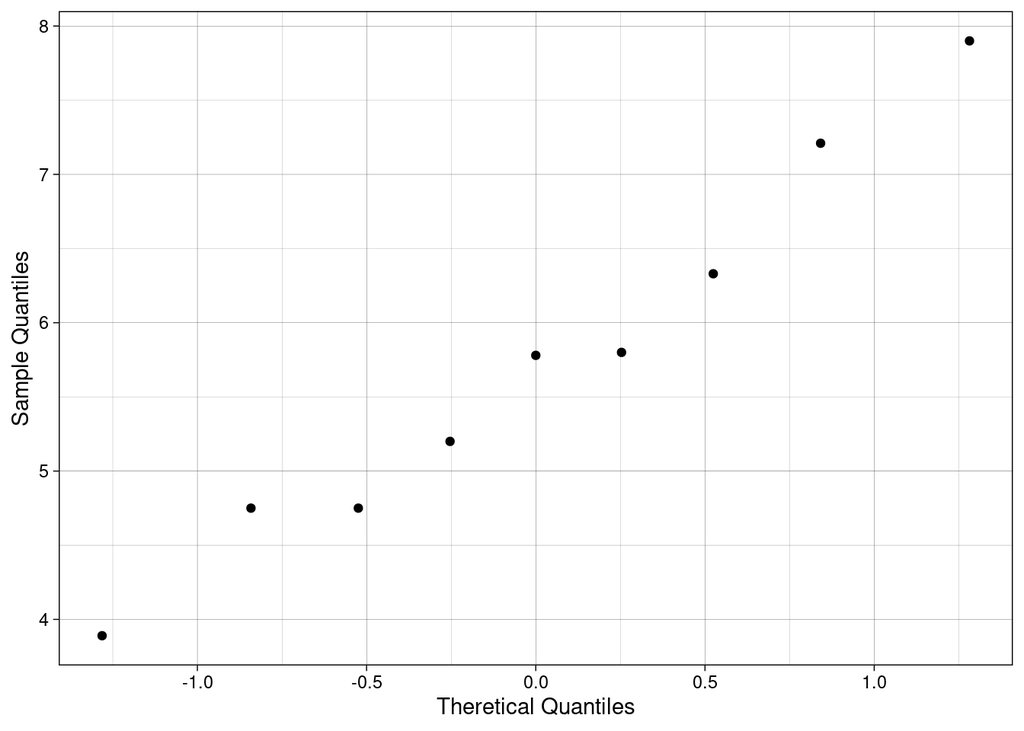

```r
ggplot(plotdata1, aes(x = deciles, y = sample)) +
  geom_point() +
  labs(
    x = "Theretical Quantiles",
    y = "Sample Quantiles"
  ) +
  theme_linedraw()
```

#### Find the *i*th Order Statistic

In general, the *i*th ordered value (or *order statistic*) is plotted against the $\frac{i}{n + 1}$ quantile of the standard normal distribution. In other words, for $n$ values, we split the normal distribution into $n + 1$ equal chunks and find the quantile (percentile) values.

```r
n <- 9
plotdata1 %>%
  mutate(
    point_number = 1:n,
    order_statistic = point_number / (n + 1)
  )
```

```
# A tibble: 9 × 4
  sample deciles point_number order_statistic
   <dbl>   <dbl>        <int>           <dbl>
1   3.89  -1.28             1             0.1
2   4.75  -0.842            2             0.2
3   4.75  -0.524            3             0.3
4   5.2   -0.253            4             0.4
5   5.78   0                5             0.5
6   5.8    0.253            6             0.6
7   6.33   0.524            7             0.7
8   7.21   0.842            8             0.8
9   7.9    1.28             9             0.9
```

#### A General Tidyverse Algorithm

We can combine all our steps above to program a general algorith using `tidyverse` tools. If you have an existing dataset, you use that in place of creating a `tibble`. Make sure to `filter()` to eliminate any rows that have missing values in the variable you plan to plot, otherwise your $n$ will be incorrect.

```r
plotdata2 <- tibble(sample = c(3.89, 4.75, 4.75, 5.20, 5.78, 5.80, 6.33, 7.21, 7.90)) %>%
  mutate(
    point_number = row_number(),
    order_statistic = point_number / (n() + 1),
    quantile_value = qnorm(order_statistic, 0, 1)
  )
plotdata2
```

```
# A tibble: 9 × 4
  sample point_number order_statistic quantile_value
   <dbl>        <int>           <dbl>          <dbl>
1   3.89            1             0.1         -1.28
2   4.75            2             0.2         -0.842
3   4.75            3             0.3         -0.524
4   5.2             4             0.4         -0.253
5   5.78            5             0.5          0
6   5.8             6             0.6          0.253
7   6.33            7             0.7          0.524
8   7.21            8             0.8          0.842
9   7.9             9             0.9          1.28
```

### Using Statistical Software

#### Sample from a Normal Population

Notice that the aesthetics for QQ plots in ggplot2 use `sample =` rather than `x =` like our other EDA plots.

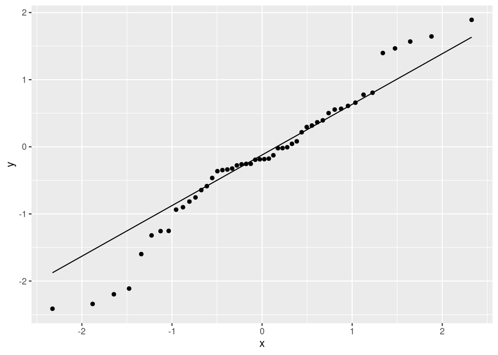

```r
normal_sample <- tibble(x = rnorm(50, 0, 1))

ggplot(normal_sample, aes(sample = x)) +
  geom_qq() +
  geom_qq_line()
```

#### Sample from a Uniform Population

The continuous uniform distribution is *platykurtic*, which means it has a flatter peak and thinner tails than the normal distribution.

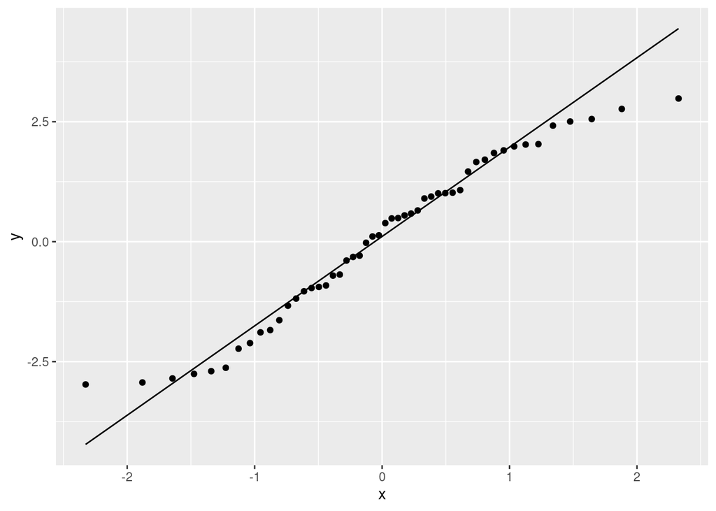

```r
# X ~ Unif(-3, +3) covers about the same range
# of values on the x-axis as a standard normal

uniform_sample <- tibble(x = runif(50, -3, +3))

ggplot(uniform_sample, aes(sample = x)) +
  geom_qq() +
  geom_qq_line()
```

#### Plotting Uniform vs. Normal Curves

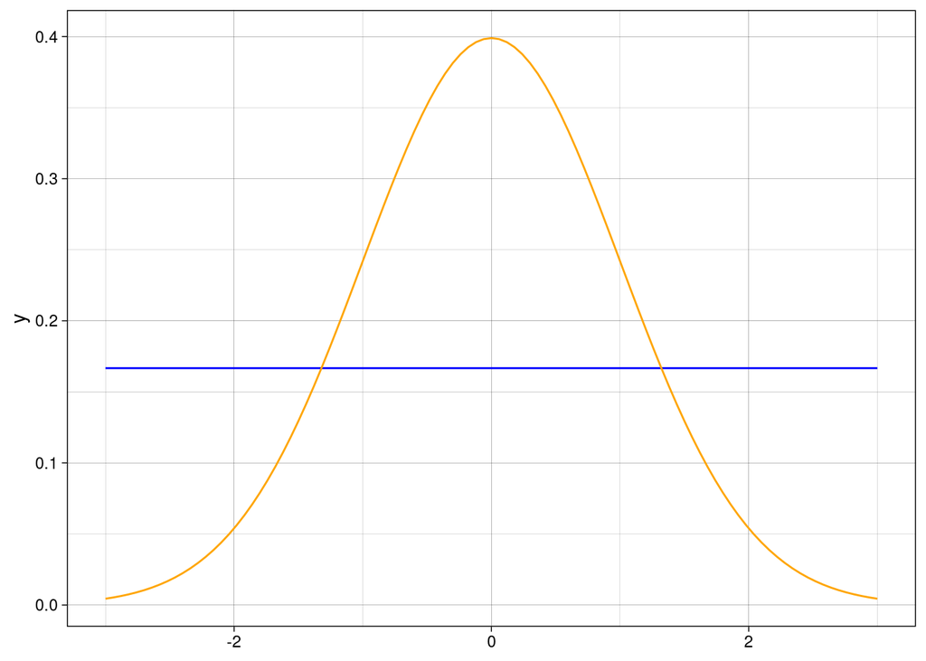

```r
ggplot() +
  stat_function(
    fun = dunif,
    args = list(-3, 3),
    color = "blue"
  ) +
  stat_function(
    fun = dnorm,
    args = list(0, 1),
    color = "orange"
  ) +
  scale_x_continuous(limits = c(-3, +3)) +
  theme_linedraw()
```

#### Sample from an Exponential Population

The exponential distribution is strongly right-skewed.

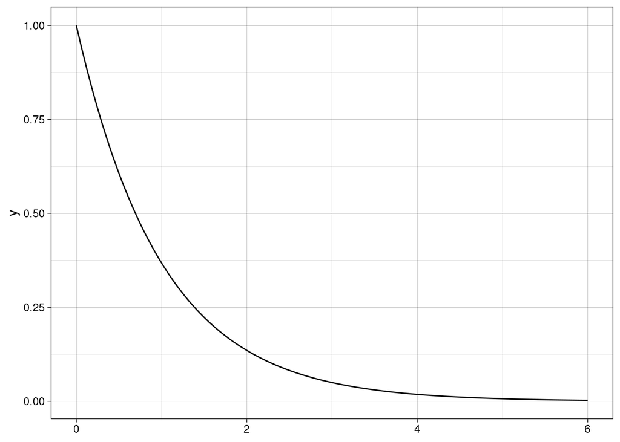

```r
# x ~ Exp(1)

exponential_sample <- tibble(x = rexp(50, 1))

# plot of the population
ggplot() +
  stat_function(
    fun = dexp,
    args = list(1)
  ) +
  scale_x_continuous(limits = c(0, 6)) +
  theme_linedraw()
```

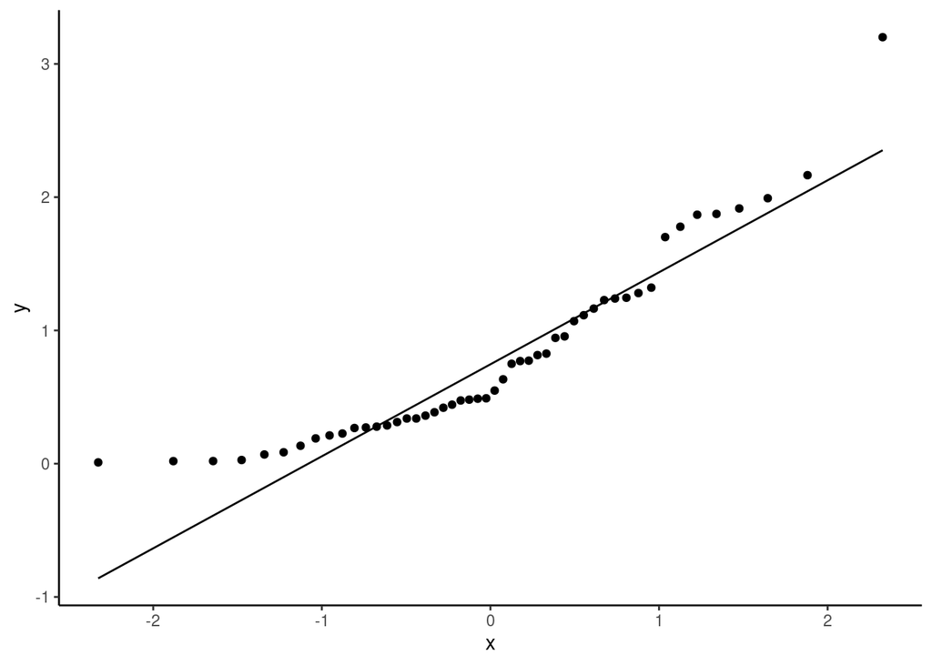

```r
ggplot(exponential_sample, aes(sample = x)) +
  geom_qq() +
  geom_qq_line() +
  theme_classic()
```

#### Sample from an Student’s t Population

The Student’s *t* distribution is *leptokurtic*, which means it has a taller peak and thicker tails than the normal distribution when the parameter is small. However, the *t* converges to the standard normal distribution as the parameter approaches $\infty$. Notice the data curves in the opposite direction from the uniform distribution on a QQ plot.

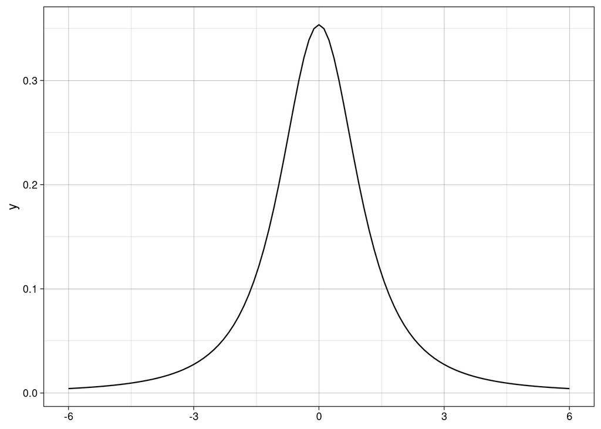

```r
# X ~ t(2)

t_sample <- tibble(x = rt(50, 2))

# plot of the population
ggplot() +
  stat_function(
    fun = dt,
    args = list(2)
  ) +
  scale_x_continuous(limits = c(-6, 6)) +
  theme_linedraw()
```

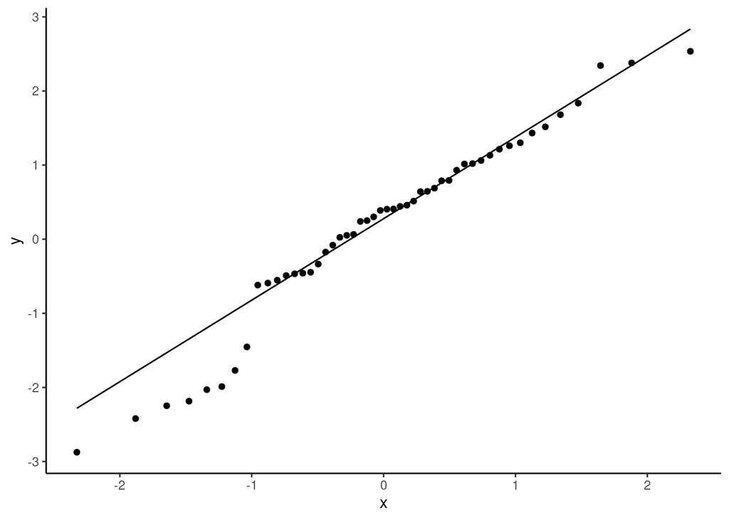

```r
# formatted plot
ggplot(t_sample, aes(sample = x)) +
  geom_qq() +
  geom_qq_line() +
  theme_classic()
```

### QQ Plots Sampling Variability

Try several samples of the same size to observe how the plot can vary from sample to sample. Also try different sample size to see how that affects the plot.

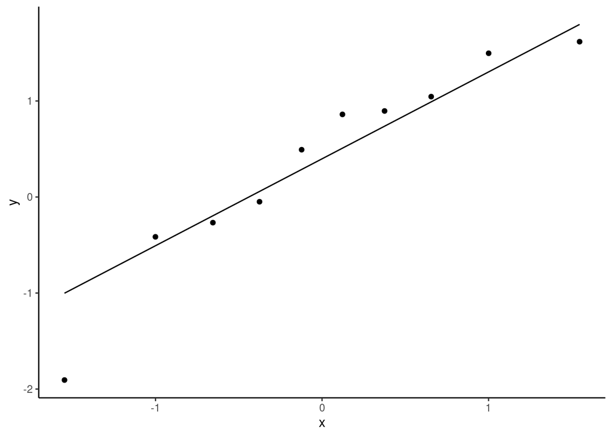

```r
# choose your sample size
n <- 10

# sample generation is nested in the plot code
ggplot(
  tibble(x = rnorm(n, 0, 1)),
  aes(sample = x)
) +
  geom_qq() +
  geom_qq_line() +
  theme_classic()
```

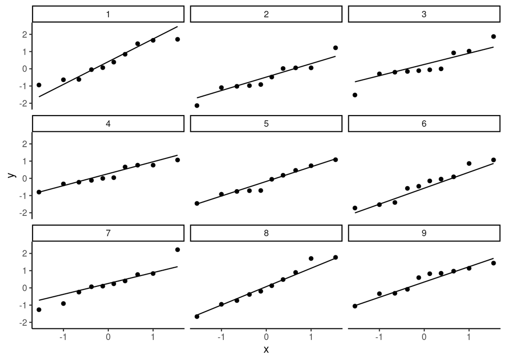

```r
# this code takes 9 samples of the indicated size

# choose your sample size
n <- 10

norm_samples <- tibble(
  sample_values = rnorm(9 * n, 0, 1),
  sample_number = rep(1:9, each = n)
)

ggplot(norm_samples, aes(sample = sample_values)) +
  geom_qq() +
  geom_qq_line() +
  facet_wrap(. ~ sample_number) +
  theme_classic()
```